# Data analysis II: Linear Mixed Models

Tuomas Eerola

26/11/2025

# 1 Repeated measures with Linear Mixed Models (LMM)

We will be using the same materials that featured in the earlier tutorials, available at Github, https://github.com/tuomaseerola/R_template. This data contains the actual data from Annaliese Grimaud’s experiment (a validation study of the expression in music) consisting of ratings of music examples representing different emotions (encoded as tracks) that were collected in two experiments. The paper titled [An Interactive Approach to Emotional Expression Through Musical Cues](https://journals.sagepub.com/doi/10.1177/20592043211061745) just came out in Music & Science.

If you still have these materials from the previous session, good. If not, get a fresh copy from github by downling whole [package](https://github.com/tuomaseerola/R_template). Make sure it runs in your *RStudio*.

# 2 Background

The data is documented and preprocessed in the `contents.R` file, which we have gone through previously. We also have gone through the basic statistics (*t-test*, *correlation*, *anova*) via the examples in the book draft. However, most of the experiments in our field collect **multiple observations from the same participants**. In the terminology of experiments, most experiments are *within-subject experiments*, which requires slight adjustment to the basic analysis of t-tests or anovas since each response is not sampled from a group of people but initially from an individual who then represents the sample. This is not a problem but actually an advantage, since it is economical to collect the data where there are multiple observations from participants and one will be able to deal with the different variation of the responses that individuals tend to have.

## 2.1 Example

Let’s load the existing data first (this is from `contents.R`).

```r
rm(list=ls(all=TRUE))                     # Cleans the R memory, just in case
source('scr/load_libraries.R')            # Loads the necessary R libraries
```

```
## The following libraries were loaded: ggplot2 psych dplyr reshape2 stringr tidyr stringr lme4 lmerTest emmeans knitr pbkrtest
```

```r
#### READ data (from Qualtrics TSV)  ---------------------------------------------------------
source('scr/read_data_survey.R')          # Produces data matrix v with a lot of variables
```

```
## N x Variables:119 131
```

```r
#### MUNGE data (preprocess, recode, etc.)  --------------------------------------------------
source('munge/rename_variables.R')        # Renames most of the columns in the v
source('munge/recode_instruments.R')      # Produces df from v that contains all data in long form
```

```
## [1] "Raw data: N= 119 and 108 variables"
## [1] "Trimmed data: N= 91"
```

So, nothing new so far but we have the data in **long-format** (`df` has 8918 observations in 9 columns, certainly repeated data).

```r
head(df)
```

```
## # A tibble: 6 × 9
##    Time   Age Gender PID   MusicalExpertiseBinary Rating Track   Source Scale
##   <int> <int> <fct>  <fct> <fct>                   <int> <fct>   <fct>  <fct>
## 1   628    26 Female S1    Musician                    5 Sadness Exp1   SADNESS
## 2   628    26 Female S1    Musician                    3 Sadness Exp1   CALMNESS
## 3   628    26 Female S1    Musician                    1 Sadness Exp1   JOY
## 4   628    26 Female S1    Musician                    1 Sadness Exp1   ANGER
## 5   628    26 Female S1    Musician                    2 Sadness Exp1   FEAR
## 6   628    26 Female S1    Musician                    1 Sadness Exp1   POWER
```

### 2.1.1 Let’s select and visualise a subset of the data

Let’s select ratings of sadness to focus on one emotion in the following examples.

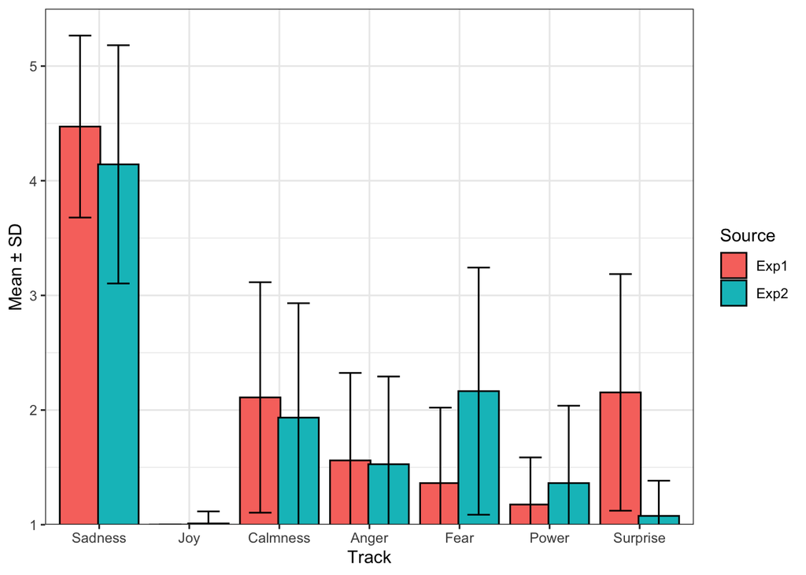

```r
tmp <- dplyr::filter(df,Scale=='SADNESS') # Get sadness ratings

pd<-position_dodge(.85)
fig1 <- tmp %>%
  group_by(Track,Source) %>%
  summarise(mean= mean(Rating),stdev = sd(Rating),.groups="drop") %>%
  ggplot(aes(x = Track,y = mean,fill=Source),position=pd)+
  geom_col(aes(x = Track,y = mean),colour='black',show.legend = TRUE,position=pd)+
  geom_errorbar(aes(x = Track,y = mean,ymin=mean-stdev,ymax=mean+stdev),width=0.5, position=pd)+
  scale_y_continuous(breaks = seq(1,5,by=1), expand = c(0,0))+
  coord_cartesian(ylim = c(1, 5.5)) +
  ylab('Mean ± SD')+
  theme_bw()
print(fig1)
```

### 2.1.2 Repeated measures ANOVA

To check whether the ratings sadness are different for the different tracks representing emotions, you would run an analysis of variance. Traditionally you run analysis of variance (ANOVA) when comparing the groups and when you have repeated measures data, you had an extension to the analysis. In basic R, this is easy. We first choose one rating scale, this time sadness, and then test whether the participants gave different ratings of sadness across `Tracks` (representing different emotions) and `Source` (representing two experiments).

```r
AOV.repeated <- aov(Rating ~ Track * Source + Error(PID/(Track * Source)), data = tmp)
print(summary(AOV.repeated))
```

```
##
## Error: PID
##           Df Sum Sq Mean Sq F value Pr(>F)
## Residuals 90  161.5   1.794
##
## Error: PID:Track
##            Df Sum Sq Mean Sq F value Pr(>F)
## Track       6 1315.6  219.27   372.3 <2e-16 ***
## Residuals 540  318.1    0.59
## ---
## Signif. codes:  0 '***' 0.001 '**' 0.01 '*' 0.05 '.' 0.1 ' ' 1
##
## Error: PID:Source
##           Df Sum Sq Mean Sq F value Pr(>F)
## Source     1   2.46   2.462   6.063 0.0157 *
## Residuals 90  36.54   0.406
## ---
## Signif. codes:  0 '***' 0.001 '**' 0.01 '*' 0.05 '.' 0.1 ' ' 1
##
## Error: PID:Track:Source
##               Df Sum Sq Mean Sq F value Pr(>F)
## Track:Source   6  87.58  14.597   34.51 <2e-16 ***
## Residuals    540 228.42   0.423
## ---
## Signif. codes:  0 '***' 0.001 '**' 0.01 '*' 0.05 '.' 0.1 ' ' 1
```

We see main effects in Tracks and Sources and also an interaction (Track:Source is significant above). However, repeated measures ANOVA is somewhat old-fashioned and it is never better than mixed models. It does not cope with non-normality well, it cannot cope with missing data, it cannot deal with unbalanced data (different repeats for different individuals). It is also difficult to construct. So we turn into more contemporary way of doing this.

### 2.1.3 Mixed Effects Models

In general, Mixed Effects Models can be linear or non-linear. Broadly they both are under *Generalised Linear Mixed Models* (GLLMs), but here we assume that the underlying distribution are normal and we apply linear models, so our Mixed Effects Models is actually a *Linear Mixed Model* (abrreviated as LMM).

LMM breaks down the variance into *fixed* and *random effects*. This breakdown relates to the research question and design, not the technicalities of the variables.

- *Fixed effects* are variables that we expect to have an effect on the dependent variable
- *Random effects* aretypically grouping factors for which we are trying to control. They are always categorical, and there are usually more than 5 levels in them. We are not that interested in the random effects but we know that these might influence the results effects.

Using `lme4` library, we will fit the random effect using the syntax `(1|variableName)` to explore how the Tracks and Sources differed when the same participants gave multiple responses. In effect our random factor is participants (PID), and we are interested in the Track and Source and their interaction. This is the simplest case of LMM.

```r
library(lme4)
m1 <- lmer(Rating ~ Track * Source + (1|PID), data=tmp)
summary(m1)
```

```
## Linear mixed model fit by REML. t-tests use Satterthwaite's method [
## lmerModLmerTest]
## Formula: Rating ~ Track * Source + (1 | PID)
##    Data: tmp
##
## REML criterion at convergence: 2876.6
##
## Scaled residuals:
##     Min      1Q  Median      3Q     Max
## -4.4036 -0.5561 -0.0786  0.4805  4.1712
##
## Random effects:
##  Groups   Name        Variance Std.Dev.
##  PID      (Intercept) 0.09257  0.3042
##  Residual             0.49831  0.7059
## Number of obs: 1274, groups:  PID, 91
##
## Fixed effects:
##                            Estimate Std. Error         df t value Pr(>|t|)
## (Intercept)                 4.47253    0.08058  955.24017  55.504  < 2e-16 ***
## TrackJoy                   -3.47253    0.10465 1170.00000 -33.182  < 2e-16 ***
## TrackCalmness              -2.36264    0.10465 1170.00000 -22.576  < 2e-16 ***
## TrackAnger                 -2.91209    0.10465 1170.00000 -27.827  < 2e-16 ***
## TrackFear                  -3.10989    0.10465 1170.00000 -29.717  < 2e-16 ***
## TrackPower                 -3.29670    0.10465 1170.00000 -31.502  < 2e-16 ***
## TrackSurprise              -2.31868    0.10465 1170.00000 -22.156  < 2e-16 ***
## SourceExp2                 -0.32967    0.10465 1170.00000  -3.150 0.001673 **
## TrackJoy:SourceExp2         0.34066    0.14800 1170.00000   2.302 0.021524 *
## TrackCalmness:SourceExp2    0.15385    0.14800 1170.00000   1.040 0.298785
## TrackAnger:SourceExp2       0.29670    0.14800 1170.00000   2.005 0.045219 *
## TrackFear:SourceExp2        1.13187    0.14800 1170.00000   7.648 4.25e-14 ***
## TrackPower:SourceExp2       0.51648    0.14800 1170.00000   3.490 0.000501 ***
## TrackSurprise:SourceExp2   -0.74725    0.14800 1170.00000  -5.049 5.15e-07 ***
## ---
## Signif. codes:  0 '***' 0.001 '**' 0.01 '*' 0.05 '.' 0.1 ' ' 1
```

```
##
## Correlation matrix not shown by default, as p = 14 > 12.
## Use print(x, correlation=TRUE)  or
##     vcov(x)        if you need it
```

That’s a lot of comparisons. We can simplify these comparison to check the aspects of the analysis that are interested in and also, if we run a lot of comparison, we need to consider multiple corrections for running so many different tests. There is another handy R package called `emmeans` which allows to construct all sorts comparison of the factors after the mixed effects models.

Let’s just focus on `Tracks`, and test which tracks differ from each other in the emotion ratings (this is from `compare_means.R` in the existing scripts). We now do this across the experiments (we drop the `Source` from the analysis, although we could keep it in).

```r
library(emmeans)  # load the library
m_tracks <- lmer(Rating ~ Track + (1|PID), data=tmp) # Analysis of ratings across Tracks
emm1<- emmeans(m_tracks, specs = pairwise ~ Track,adjust="bonferroni") # are emotions different between all pairings of the tracks?
emm1
```

```
## $emmeans
##  Track    emmean    SE  df lower.CL upper.CL
##  Sadness    4.31 0.064 597     4.18     4.43
##  Joy        1.01 0.064 597     0.88     1.13
##  Calmness   2.02 0.064 597     1.90     2.15
##  Anger      1.54 0.064 597     1.42     1.67
##  Fear       1.76 0.064 597     1.64     1.89
##  Power      1.27 0.064 597     1.14     1.40
##  Surprise   1.62 0.064 597     1.49     1.74
##
## Degrees-of-freedom method: kenward-roger
## Confidence level used: 0.95
##
## $contrasts
##  contrast            estimate     SE   df t.ratio p.value
##  Sadness - Joy         3.3022 0.0793 1177  41.656  <.0001
##  Sadness - Calmness    2.2857 0.0793 1177  28.834  <.0001
##  Sadness - Anger       2.7637 0.0793 1177  34.864  <.0001
##  Sadness - Fear        2.5440 0.0793 1177  32.091  <.0001
##  Sadness - Power       3.0385 0.0793 1177  38.329  <.0001
##  Sadness - Surprise    2.6923 0.0793 1177  33.963  <.0001
##  Joy - Calmness       -1.0165 0.0793 1177 -12.823  <.0001
##  Joy - Anger          -0.5385 0.0793 1177  -6.793  <.0001
##  Joy - Fear           -0.7582 0.0793 1177  -9.565  <.0001
##  Joy - Power          -0.2637 0.0793 1177  -3.327  0.0190
##  Joy - Surprise       -0.6099 0.0793 1177  -7.694  <.0001
##  Calmness - Anger      0.4780 0.0793 1177   6.030  <.0001
##  Calmness - Fear       0.2582 0.0793 1177   3.258  0.0243
##  Calmness - Power      0.7527 0.0793 1177   9.496  <.0001
##  Calmness - Surprise   0.4066 0.0793 1177   5.129  <.0001
##  Anger - Fear         -0.2198 0.0793 1177  -2.772  0.1187
##  Anger - Power         0.2747 0.0793 1177   3.466  0.0115
##  Anger - Surprise     -0.0714 0.0793 1177  -0.901  1.0000
##  Fear - Power          0.4945 0.0793 1177   6.238  <.0001
##  Fear - Surprise       0.1484 0.0793 1177   1.871  1.0000
##  Power - Surprise     -0.3462 0.0793 1177  -4.367  0.0003
##
## Degrees-of-freedom method: kenward-roger
## P value adjustment: bonferroni method for 21 tests
```

What is our interpretation here?

Or we can focus on `Source` to check whether the ratings across tracks were different in the two experiments:

```r
m_source <- lmer(Rating ~ Source + (1|PID), data=tmp)
emm2<- emmeans(m_source, specs = pairwise ~ Source) # are emotions different between Experiments?
emm2
```

```
## $emmeans
##  Source emmean     SE  df lower.CL upper.CL
##  Exp1     1.98 0.0522 316     1.87     2.08
##  Exp2     1.89 0.0522 316     1.79     1.99
##
## Degrees-of-freedom method: kenward-roger
## Confidence level used: 0.95
##
## $contrasts
##  contrast    estimate     SE   df t.ratio p.value
##  Exp1 - Exp2   0.0879 0.0726 1182   1.210  0.2264
##
## Degrees-of-freedom method: kenward-roger
```

And here the interpretation is pretty simple.

In both of these cases we have fitted so-called *random-intercept models*, where each participant has a different intercept. In some cases, this is not unrealistic and some samples/populations come systematically with different assumptions. For instance, some participants may come from certain ensembles/orchestra or schools, and in these cases, we can specify random-slope and random-intercept model, where we allow the intercepts to be influenced by this grouping variable.

Here we compared all pairs of emotions to each other, but one can also specify whatever contrasts one is interested in (positive emotions vs negative emotions, or sadness vs all other emotions or…).

One can also plot group differences with the `emmeans` functions.

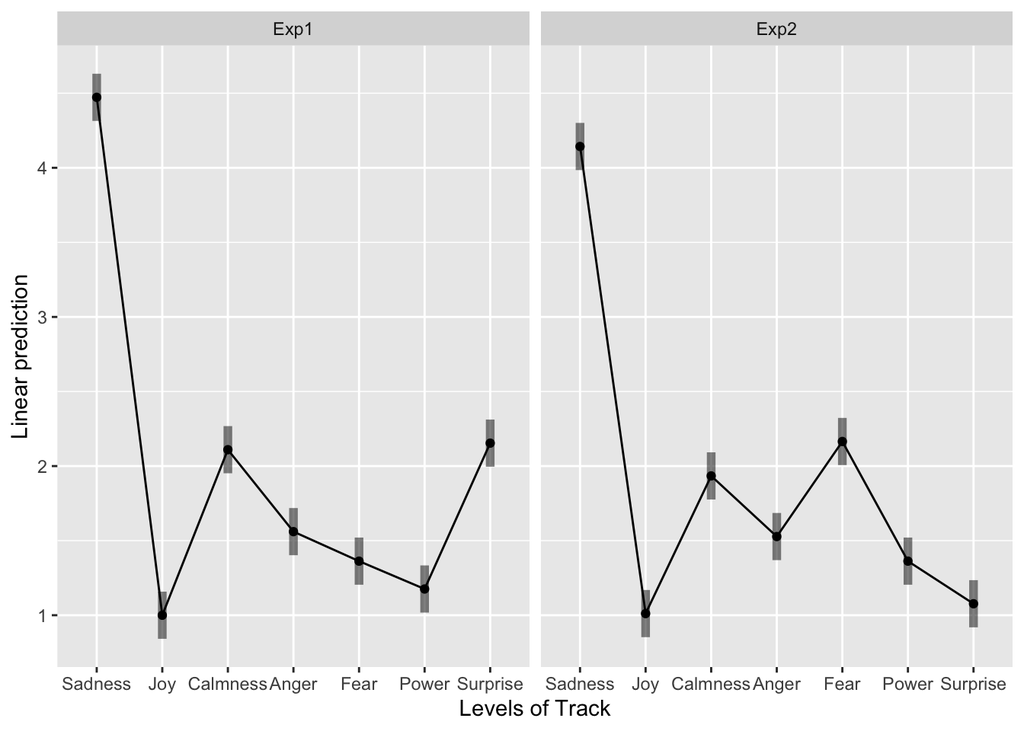

```r
m1 <- lmer(Rating ~ Track * Source + (1|PID), data=tmp)
emmip(m1, ~ Track  | Source, CIs = TRUE)
```

In conclusion, `lme4` for LMMs enhanced with `emmeans` allow you to analyse almost any combination of repeated measures data that could even have non-normal distributions, missing observations, and non-symmetrical designs. It is a versatile tool but it also requires time to get familiar with.

# 3 Further information

## 3.1 LMM models

- [Introduction to linear mixed models](https://ourcodingclub.github.io/tutorials/mixed-models/)
- [Linear mixed-effects models for within-participant psychology experiments](https://www.frontiersin.org/articles/10.3389/fpsyg.2015.00002/full)
- bw_LME_tutorial.pdf

## 3.2 Repeated measures

- [Repeated measures ANOVA in R](https://www.datanovia.com/en/lessons/repeated-measures-anova-in-r/)